# Alleged Child Victims by Race Neighborhood-Level Report

March 08, 2021

# Overall Summary

- This report summarizes 6976 ACVs with decision dates between 2020-01-01 and 2020-12-31.
- 64 (0.9%) ACVs had an address that was not able to be geocoded.
- 1516 (46.9%) **White ACVs** were **screened in**. 1077 (33.3%) **White ACVs** were **screened out**.
- 1357 (47%) **Black/African American ACVs** were **screened in**. 952 (33%) **Black/African American ACVs** were **screened out**.
- There were 794 ACVs of **neither** White nor Black/African American race.
- 385 (48.7%) **Non-White nor Black/African American ACVs** were **screened in**. 242 (30.6%) **Non-White nor Black/African American ACVs** were **screened out**.

# Neighborhood Summary

The table below summarizes ACVs, screening decision, race, and demographic information by neighborhood. The table can be sorted by clicking on the column name or searched using the search box.

|  | Neighborhood | Number of ACVs | ACVs Screened In | Population Under 18 | Number ACVs per 1000 Children | Fraction of ACVs Screened In | Number of White ACVs | White ACVs per 1000 Children | White ACVs Screened In | Fraction of White ACVs Screened In | Number of Black/African American ACVs | Black/African American ACVs per 1000 Children | Black/African American ACVs Screened In | Fraction of Black/African American ACVs Screened In | Deprivation Index |
| --- | --- | --- | --- | --- | --- | --- | --- | --- | --- | --- | --- | --- | --- | --- | --- |
| 1 | Amberley | 36 | 14 | 7144 | 5.04 | 0.39 | 18 | 2.52 | 11 | 0.61 | 18 | 2.52 |  |  | 0.17 |
| 2 | Anderson Twp.-Newtown | 408 | 199 | 79306 | 5.14 | 0.49 | 219 | 2.76 | 108 | 0.49 | 189 | 2.38 | 91 | 0.48 | 0.25 |
| 3 | Avondale | 58 | 25 | 21449 | 2.7 | 0.43 | 38 | 1.77 | 18 | 0.47 | 20 | 0.93 |  |  | 0.63 |
| 4 | Blue Ash | 111 | 53 | 21862 | 5.08 | 0.48 | 55 | 2.52 | 30 | 0.55 | 56 | 2.56 | 23 | 0.41 | 0.25 |
| 5 | Bond Hill | 61 | 32 | 11312 | 5.39 | 0.52 | 34 | 3.01 | 18 | 0.53 | 27 | 2.39 | 14 | 0.52 | 0.47 |
| 6 | Camp Washington |  |  | 2363 |  |  |  |  |  |  |  |  |  |  | 0.57 |
| 7 | Carthage | 17 | 10 | 5072 | 3.35 | 0.59 | 10 | 1.97 |  |  |  |  |  |  | 0.66 |
| 8 | Cheviot | 70 | 39 | 14891 | 4.7 | 0.56 | 32 | 2.15 | 16 | 0.5 | 38 | 2.55 | 23 | 0.61 | 0.4 |
| 9 | Clifton | 65 | 32 | 14180 | 4.58 | 0.49 | 32 | 2.26 | 18 | 0.56 | 33 | 2.33 | 14 | 0.42 | 0.37 |
| 10 | Colerain Twp. | 467 | 208 | 90998 | 5.13 | 0.45 | 258 | 2.84 | 107 | 0.41 | 209 | 2.3 | 101 | 0.48 | 0.34 |

[output cut: 71 more lines]

## Neighborhood Maps

The maps below are interactive and can be panned and zoomed. Clicking on a neighborhood will provide a pop-up with more information about that neighborhood.

### ACVs per 1000 Children

The two maps below show the ACV Rate (number of acvs per 1000 children) by neighborhood and by race.

[interactive chart not shown]

### Fraction of ACVs Screened In

The two maps below show the Fraction of ACVs Screened In (number of ACVs that were screened in / number of ACVs) by neighborhood and by race.

[interactive chart not shown]

## Percent ACVs Screened In Over Time

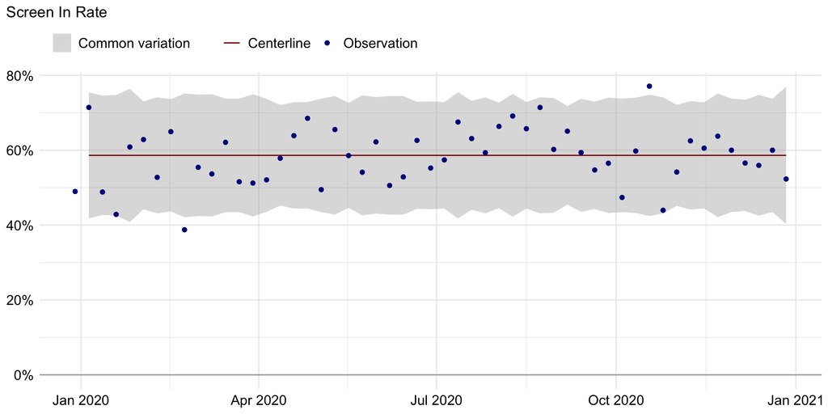

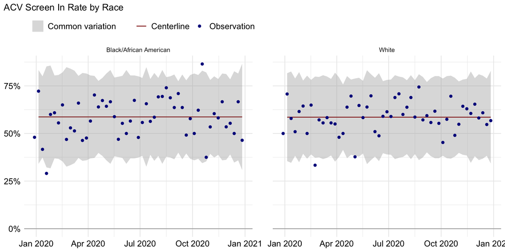